# Risk Factor Analysis

## Outcome Variable

**Outcome Variable:** y_rate_haz

## Predictor Variables

**Intervention Variable:** predfeed6

**Adjustment Set:**

unadjusted

## Stratifying Variables

The analysis was stratified on these variable(s):

- agecat
- studyid
- country

## Data Summary

| agecat | studyid | country | predfeed6 | n_cell | n |
| --- | --- | --- | --- | --- | --- |
| 0-3 months | ki0047075b-MAL-ED | BANGLADESH | 0 | 112 | 233 |
| 0-3 months | ki0047075b-MAL-ED | BANGLADESH | 1 | 121 | 233 |
| 0-3 months | ki0047075b-MAL-ED | BRAZIL | 0 | 148 | 175 |
| 0-3 months | ki0047075b-MAL-ED | BRAZIL | 1 | 27 | 175 |
| 0-3 months | ki0047075b-MAL-ED | INDIA | 0 | 178 | 193 |
| 0-3 months | ki0047075b-MAL-ED | INDIA | 1 | 15 | 193 |
| 0-3 months | ki0047075b-MAL-ED | NEPAL | 0 | 150 | 173 |
| 0-3 months | ki0047075b-MAL-ED | NEPAL | 1 | 23 | 173 |
| 0-3 months | ki0047075b-MAL-ED | PERU | 0 | 150 | 258 |
| 0-3 months | ki0047075b-MAL-ED | PERU | 1 | 108 | 258 |
| 0-3 months | ki0047075b-MAL-ED | SOUTH AFRICA | 0 | 206 | 209 |
| 0-3 months | ki0047075b-MAL-ED | SOUTH AFRICA | 1 | 3 | 209 |
| 0-3 months | ki0047075b-MAL-ED | TANZANIA, UNITED REPUBLIC OF | 0 | 223 | 224 |
| 0-3 months | ki0047075b-MAL-ED | TANZANIA, UNITED REPUBLIC OF | 1 | 1 | 224 |
| 0-3 months | ki1000109-EE | PAKISTAN | 0 | 260 | 594 |
| 0-3 months | ki1000109-EE | PAKISTAN | 1 | 334 | 594 |
| 0-3 months | kiGH5241-JiVitA-3 | BANGLADESH | 0 | 8676 | 40078 |
| 0-3 months | kiGH5241-JiVitA-3 | BANGLADESH | 1 | 31402 | 40078 |
| 0-3 months | kiGH5241-JiVitA-4 | BANGLADESH | 0 | 586 | 3610 |
| 0-3 months | kiGH5241-JiVitA-4 | BANGLADESH | 1 | 3024 | 3610 |
| 3-6 months | ki0047075b-MAL-ED | BANGLADESH | 0 | 108 | 225 |
| 3-6 months | ki0047075b-MAL-ED | BANGLADESH | 1 | 117 | 225 |
| 3-6 months | ki0047075b-MAL-ED | BRAZIL | 0 | 173 | 208 |
| 3-6 months | ki0047075b-MAL-ED | BRAZIL | 1 | 35 | 208 |
| 3-6 months | ki0047075b-MAL-ED | INDIA | 0 | 207 | 225 |
| 3-6 months | ki0047075b-MAL-ED | INDIA | 1 | 18 | 225 |
| 3-6 months | ki0047075b-MAL-ED | NEPAL | 0 | 205 | 232 |
| 3-6 months | ki0047075b-MAL-ED | NEPAL | 1 | 27 | 232 |
| 3-6 months | ki0047075b-MAL-ED | PERU | 0 | 153 | 264 |
| 3-6 months | ki0047075b-MAL-ED | PERU | 1 | 111 | 264 |

[output cut: 60 more lines]

The following strata were considered:

- agecat: 0-3 months, studyid: ki0047075b-MAL-ED, country: BANGLADESH
- agecat: 0-3 months, studyid: ki0047075b-MAL-ED, country: BRAZIL
- agecat: 0-3 months, studyid: ki0047075b-MAL-ED, country: INDIA
- agecat: 0-3 months, studyid: ki0047075b-MAL-ED, country: NEPAL
- agecat: 0-3 months, studyid: ki0047075b-MAL-ED, country: PERU
- agecat: 0-3 months, studyid: ki0047075b-MAL-ED, country: SOUTH AFRICA
- agecat: 0-3 months, studyid: ki0047075b-MAL-ED, country: TANZANIA, UNITED REPUBLIC OF
- agecat: 0-3 months, studyid: ki1000109-EE, country: PAKISTAN
- agecat: 0-3 months, studyid: kiGH5241-JiVitA-3, country: BANGLADESH
- agecat: 0-3 months, studyid: kiGH5241-JiVitA-4, country: BANGLADESH
- agecat: 12-24 months, studyid: ki0047075b-MAL-ED, country: BANGLADESH
- agecat: 12-24 months, studyid: ki0047075b-MAL-ED, country: BRAZIL
- agecat: 12-24 months, studyid: ki0047075b-MAL-ED, country: INDIA
- agecat: 12-24 months, studyid: ki0047075b-MAL-ED, country: NEPAL
- agecat: 12-24 months, studyid: ki0047075b-MAL-ED, country: PERU
- agecat: 12-24 months, studyid: ki0047075b-MAL-ED, country: SOUTH AFRICA
- agecat: 12-24 months, studyid: ki0047075b-MAL-ED, country: TANZANIA, UNITED REPUBLIC OF
- agecat: 12-24 months, studyid: ki1113344-GMS-Nepal, country: NEPAL
- agecat: 12-24 months, studyid: ki1148112-LCNI-5, country: MALAWI
- agecat: 12-24 months, studyid: kiGH5241-JiVitA-3, country: BANGLADESH
- agecat: 12-24 months, studyid: kiGH5241-JiVitA-4, country: BANGLADESH
- agecat: 3-6 months, studyid: ki0047075b-MAL-ED, country: BANGLADESH
- agecat: 3-6 months, studyid: ki0047075b-MAL-ED, country: BRAZIL
- agecat: 3-6 months, studyid: ki0047075b-MAL-ED, country: INDIA
- agecat: 3-6 months, studyid: ki0047075b-MAL-ED, country: NEPAL
- agecat: 3-6 months, studyid: ki0047075b-MAL-ED, country: PERU
- agecat: 3-6 months, studyid: ki0047075b-MAL-ED, country: SOUTH AFRICA
- agecat: 3-6 months, studyid: ki0047075b-MAL-ED, country: TANZANIA, UNITED REPUBLIC OF
- agecat: 3-6 months, studyid: ki1000109-EE, country: PAKISTAN
- agecat: 3-6 months, studyid: ki1113344-GMS-Nepal, country: NEPAL
- agecat: 3-6 months, studyid: kiGH5241-JiVitA-3, country: BANGLADESH
- agecat: 3-6 months, studyid: kiGH5241-JiVitA-4, country: BANGLADESH
- agecat: 6-12 months, studyid: ki0047075b-MAL-ED, country: BANGLADESH
- agecat: 6-12 months, studyid: ki0047075b-MAL-ED, country: BRAZIL
- agecat: 6-12 months, studyid: ki0047075b-MAL-ED, country: INDIA
- agecat: 6-12 months, studyid: ki0047075b-MAL-ED, country: NEPAL
- agecat: 6-12 months, studyid: ki0047075b-MAL-ED, country: PERU
- agecat: 6-12 months, studyid: ki0047075b-MAL-ED, country: SOUTH AFRICA
- agecat: 6-12 months, studyid: ki0047075b-MAL-ED, country: TANZANIA, UNITED REPUBLIC OF
- agecat: 6-12 months, studyid: ki1000109-EE, country: PAKISTAN
- agecat: 6-12 months, studyid: ki1000304b-SAS-FoodSuppl, country: INDIA
- agecat: 6-12 months, studyid: ki1113344-GMS-Nepal, country: NEPAL
- agecat: 6-12 months, studyid: ki1148112-LCNI-5, country: MALAWI
- agecat: 6-12 months, studyid: kiGH5241-JiVitA-3, country: BANGLADESH
- agecat: 6-12 months, studyid: kiGH5241-JiVitA-4, country: BANGLADESH

### Dropped Strata

Some strata were dropped due to rare outcomes:

- agecat: 0-3 months, studyid: ki0047075b-MAL-ED, country: SOUTH AFRICA
- agecat: 0-3 months, studyid: ki0047075b-MAL-ED, country: TANZANIA, UNITED REPUBLIC OF
- agecat: 3-6 months, studyid: ki0047075b-MAL-ED, country: SOUTH AFRICA
- agecat: 3-6 months, studyid: ki0047075b-MAL-ED, country: TANZANIA, UNITED REPUBLIC OF
- agecat: 6-12 months, studyid: ki0047075b-MAL-ED, country: SOUTH AFRICA
- agecat: 6-12 months, studyid: ki0047075b-MAL-ED, country: TANZANIA, UNITED REPUBLIC OF
- agecat: 6-12 months, studyid: ki1000109-EE, country: PAKISTAN
- agecat: 6-12 months, studyid: ki1000304b-SAS-FoodSuppl, country: INDIA
- agecat: 12-24 months, studyid: ki0047075b-MAL-ED, country: SOUTH AFRICA
- agecat: 12-24 months, studyid: ki0047075b-MAL-ED, country: TANZANIA, UNITED REPUBLIC OF

## Methods Detail

We’re interested in the causal parameters $E[Y_a]$ for all values of $a \in \mathcal{A}$. These parameters represent the mean outcome if, possibly contrary to fact, we intervened to set all units to have $A=a$. Under the randomization and positivity assumptions, these are identified by the statistical parameters $\psi_a=E_W[E_{Y|A,W}(Y|A=a,W)]$. In addition, we’re interested in the mean of $Y$, $E[Y]$ under no intervention (the observed mean). We will estimate these parameters by using SuperLearner to fit the relevant likelihood factors – $E_{Y|A,W}(Y|A=a,W)$ and $p(A=a|W)$, and then updating our likelihood fit using a joint TMLE.

For unadjusted analyses ($W=\{\}$), initial likelihoods were estimated using Lrnr_glm to estimate the simple $E(Y|A)$ and Lrnr_mean to estimate $p(A)$. For adjusted analyses, a small library containing Lrnr_glmnet, Lrnr_xgboost, and Lrnr_mean was used.

# Results Detail

## Results Plots

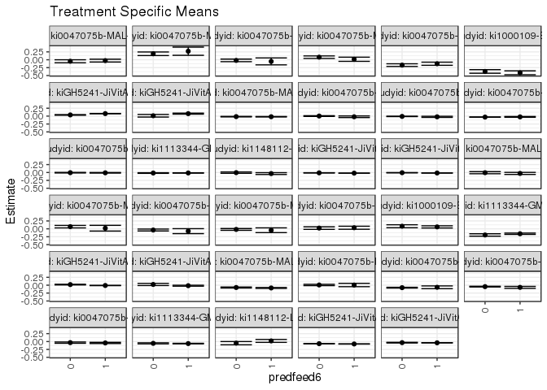

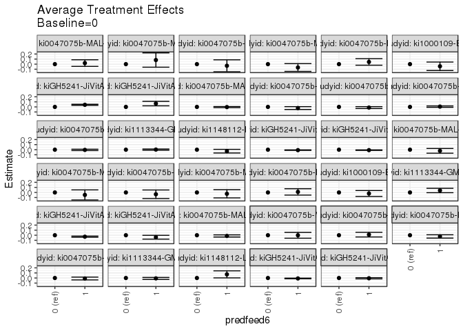

## Results Table

### Parameter: TSM

| agecat | studyid | country | intervention_level | baseline_level | estimate | ci_lower | ci_upper |
| --- | --- | --- | --- | --- | --- | --- | --- |
| 0-3 months | ki0047075b-MAL-ED | BANGLADESH | 0 | NA | -0.0476565 | -0.0950372 | -0.0002758 |
| 0-3 months | ki0047075b-MAL-ED | BANGLADESH | 1 | NA | -0.0267509 | -0.0712627 | 0.0177609 |
| 0-3 months | ki0047075b-MAL-ED | BRAZIL | 0 | NA | 0.1899384 | 0.1331176 | 0.2467593 |
| 0-3 months | ki0047075b-MAL-ED | BRAZIL | 1 | NA | 0.2710311 | 0.1415500 | 0.4005122 |
| 0-3 months | ki0047075b-MAL-ED | INDIA | 0 | NA | -0.0197838 | -0.0607732 | 0.0212055 |
| 0-3 months | ki0047075b-MAL-ED | INDIA | 1 | NA | -0.0518390 | -0.1615837 | 0.0579057 |
| 0-3 months | ki0047075b-MAL-ED | NEPAL | 0 | NA | 0.0823695 | 0.0429595 | 0.1217794 |
| 0-3 months | ki0047075b-MAL-ED | NEPAL | 1 | NA | 0.0159974 | -0.0501167 | 0.0821114 |
| 0-3 months | ki0047075b-MAL-ED | PERU | 0 | NA | -0.1691767 | -0.2115418 | -0.1268117 |
| 0-3 months | ki0047075b-MAL-ED | PERU | 1 | NA | -0.1254340 | -0.1747977 | -0.0760704 |
| 0-3 months | ki1000109-EE | PAKISTAN | 0 | NA | -0.3700656 | -0.4267848 | -0.3133464 |
| 0-3 months | ki1000109-EE | PAKISTAN | 1 | NA | -0.4123678 | -0.4738081 | -0.3509274 |
| 0-3 months | kiGH5241-JiVitA-3 | BANGLADESH | 0 | NA | 0.0379405 | 0.0280783 | 0.0478026 |
| 0-3 months | kiGH5241-JiVitA-3 | BANGLADESH | 1 | NA | 0.0795754 | 0.0742225 | 0.0849282 |
| 0-3 months | kiGH5241-JiVitA-4 | BANGLADESH | 0 | NA | 0.0120474 | -0.0293004 | 0.0533952 |
| 0-3 months | kiGH5241-JiVitA-4 | BANGLADESH | 1 | NA | 0.0782100 | 0.0624297 | 0.0939903 |
| 3-6 months | ki0047075b-MAL-ED | BANGLADESH | 0 | NA | -0.0071456 | -0.0404687 | 0.0261776 |
| 3-6 months | ki0047075b-MAL-ED | BANGLADESH | 1 | NA | -0.0296737 | -0.0623525 | 0.0030051 |
| 3-6 months | ki0047075b-MAL-ED | BRAZIL | 0 | NA | 0.0686947 | 0.0289451 | 0.1084443 |
| 3-6 months | ki0047075b-MAL-ED | BRAZIL | 1 | NA | 0.0199377 | -0.0710783 | 0.1109537 |
| 3-6 months | ki0047075b-MAL-ED | INDIA | 0 | NA | -0.0373705 | -0.0678959 | -0.0068452 |
| 3-6 months | ki0047075b-MAL-ED | INDIA | 1 | NA | -0.0729375 | -0.1514603 | 0.0055853 |
| 3-6 months | ki0047075b-MAL-ED | NEPAL | 0 | NA | -0.0186830 | -0.0471850 | 0.0098189 |
| 3-6 months | ki0047075b-MAL-ED | NEPAL | 1 | NA | -0.0447744 | -0.1204223 | 0.0308736 |
| 3-6 months | ki0047075b-MAL-ED | PERU | 0 | NA | 0.0238785 | -0.0168086 | 0.0645657 |
| 3-6 months | ki0047075b-MAL-ED | PERU | 1 | NA | 0.0348852 | -0.0131797 | 0.0829500 |
| 3-6 months | ki1000109-EE | PAKISTAN | 0 | NA | 0.0821295 | 0.0349679 | 0.1292911 |
| 3-6 months | ki1000109-EE | PAKISTAN | 1 | NA | 0.0614189 | 0.0268567 | 0.0959811 |
| 3-6 months | ki1113344-GMS-Nepal | NEPAL | 0 | NA | -0.1945556 | -0.2322587 | -0.1568526 |
| 3-6 months | ki1113344-GMS-Nepal | NEPAL | 1 | NA | -0.1558065 | -0.1771322 | -0.1344809 |
| 3-6 months | kiGH5241-JiVitA-3 | BANGLADESH | 0 | NA | 0.0193004 | 0.0087105 | 0.0298904 |
| 3-6 months | kiGH5241-JiVitA-3 | BANGLADESH | 1 | NA | -0.0096665 | -0.0149856 | -0.0043475 |
| 3-6 months | kiGH5241-JiVitA-4 | BANGLADESH | 0 | NA | 0.0234876 | -0.0108693 | 0.0578445 |
| 3-6 months | kiGH5241-JiVitA-4 | BANGLADESH | 1 | NA | -0.0158297 | -0.0310111 | -0.0006482 |
| 6-12 months | ki0047075b-MAL-ED | BANGLADESH | 0 | NA | -0.0735680 | -0.0897543 | -0.0573817 |
| 6-12 months | ki0047075b-MAL-ED | BANGLADESH | 1 | NA | -0.0878261 | -0.1017097 | -0.0739425 |
| 6-12 months | ki0047075b-MAL-ED | BRAZIL | 0 | NA | 0.0067834 | -0.0139950 | 0.0275617 |
| 6-12 months | ki0047075b-MAL-ED | BRAZIL | 1 | NA | 0.0054963 | -0.0478101 | 0.0588027 |
| 6-12 months | ki0047075b-MAL-ED | INDIA | 0 | NA | -0.0783925 | -0.0912556 | -0.0655294 |
| 6-12 months | ki0047075b-MAL-ED | INDIA | 1 | NA | -0.0669092 | -0.1107541 | -0.0230643 |
| 6-12 months | ki0047075b-MAL-ED | NEPAL | 0 | NA | -0.0456478 | -0.0569689 | -0.0343267 |
| 6-12 months | ki0047075b-MAL-ED | NEPAL | 1 | NA | -0.0692498 | -0.1000452 | -0.0384544 |
| 6-12 months | ki0047075b-MAL-ED | PERU | 0 | NA | -0.0340440 | -0.0542077 | -0.0138803 |
| 6-12 months | ki0047075b-MAL-ED | PERU | 1 | NA | -0.0439051 | -0.0628151 | -0.0249951 |
| 6-12 months | ki1113344-GMS-Nepal | NEPAL | 0 | NA | -0.0566137 | -0.0735763 | -0.0396510 |
| 6-12 months | ki1113344-GMS-Nepal | NEPAL | 1 | NA | -0.0642934 | -0.0737072 | -0.0548795 |
| 6-12 months | ki1148112-LCNI-5 | MALAWI | 0 | NA | -0.0513798 | -0.1030379 | 0.0002783 |
| 6-12 months | ki1148112-LCNI-5 | MALAWI | 1 | NA | 0.0202243 | -0.0261296 | 0.0665782 |
| 6-12 months | kiGH5241-JiVitA-3 | BANGLADESH | 0 | NA | -0.0680510 | -0.0742475 | -0.0618544 |
| 6-12 months | kiGH5241-JiVitA-3 | BANGLADESH | 1 | NA | -0.0768124 | -0.0799062 | -0.0737185 |
| 6-12 months | kiGH5241-JiVitA-4 | BANGLADESH | 0 | NA | -0.0346550 | -0.0455016 | -0.0238083 |
| 6-12 months | kiGH5241-JiVitA-4 | BANGLADESH | 1 | NA | -0.0398458 | -0.0451173 | -0.0345744 |
| 12-24 months | ki0047075b-MAL-ED | BANGLADESH | 0 | NA | -0.0159184 | -0.0241763 | -0.0076605 |
| 12-24 months | ki0047075b-MAL-ED | BANGLADESH | 1 | NA | -0.0193212 | -0.0265901 | -0.0120524 |
| 12-24 months | ki0047075b-MAL-ED | BRAZIL | 0 | NA | 0.0026860 | -0.0088201 | 0.0141922 |
| 12-24 months | ki0047075b-MAL-ED | BRAZIL | 1 | NA | -0.0200019 | -0.0459411 | 0.0059373 |
| 12-24 months | ki0047075b-MAL-ED | INDIA | 0 | NA | -0.0089242 | -0.0143251 | -0.0035234 |
| 12-24 months | ki0047075b-MAL-ED | INDIA | 1 | NA | -0.0219788 | -0.0397242 | -0.0042334 |
| 12-24 months | ki0047075b-MAL-ED | NEPAL | 0 | NA | -0.0305307 | -0.0359959 | -0.0250655 |
| 12-24 months | ki0047075b-MAL-ED | NEPAL | 1 | NA | -0.0242401 | -0.0370368 | -0.0114433 |
| 12-24 months | ki0047075b-MAL-ED | PERU | 0 | NA | -0.0065036 | -0.0164331 | 0.0034259 |
| 12-24 months | ki0047075b-MAL-ED | PERU | 1 | NA | -0.0106502 | -0.0198428 | -0.0014577 |
| 12-24 months | ki1113344-GMS-Nepal | NEPAL | 0 | NA | -0.0174101 | -0.0278073 | -0.0070130 |
| 12-24 months | ki1113344-GMS-Nepal | NEPAL | 1 | NA | -0.0155172 | -0.0213866 | -0.0096478 |
| 12-24 months | ki1148112-LCNI-5 | MALAWI | 0 | NA | -0.0053185 | -0.0263716 | 0.0157345 |
| 12-24 months | ki1148112-LCNI-5 | MALAWI | 1 | NA | -0.0345407 | -0.0639658 | -0.0051157 |
| 12-24 months | kiGH5241-JiVitA-3 | BANGLADESH | 0 | NA | -0.0119811 | -0.0160171 | -0.0079450 |
| 12-24 months | kiGH5241-JiVitA-3 | BANGLADESH | 1 | NA | -0.0209685 | -0.0229478 | -0.0189892 |
| 12-24 months | kiGH5241-JiVitA-4 | BANGLADESH | 0 | NA | -0.0074814 | -0.0117911 | -0.0031717 |
| 12-24 months | kiGH5241-JiVitA-4 | BANGLADESH | 1 | NA | -0.0164791 | -0.0187107 | -0.0142476 |

### Parameter: E(Y)

| agecat | studyid | country | intervention_level | baseline_level | estimate | ci_lower | ci_upper |
| --- | --- | --- | --- | --- | --- | --- | --- |
| 0-3 months | ki0047075b-MAL-ED | BANGLADESH | NA | NA | -0.0367999 | -0.0692784 | -0.0043215 |
| 0-3 months | ki0047075b-MAL-ED | BRAZIL | NA | NA | 0.2024499 | 0.1502269 | 0.2546728 |
| 0-3 months | ki0047075b-MAL-ED | INDIA | NA | NA | -0.0222752 | -0.0610481 | 0.0164977 |
| 0-3 months | ki0047075b-MAL-ED | NEPAL | NA | NA | 0.0735454 | 0.0381022 | 0.1089887 |
| 0-3 months | ki0047075b-MAL-ED | PERU | NA | NA | -0.1508658 | -0.1831247 | -0.1186070 |
| 0-3 months | ki1000109-EE | PAKISTAN | NA | NA | -0.3938516 | -0.4364614 | -0.3512419 |
| 0-3 months | kiGH5241-JiVitA-3 | BANGLADESH | NA | NA | 0.0705623 | 0.0656085 | 0.0755161 |
| 0-3 months | kiGH5241-JiVitA-4 | BANGLADESH | NA | NA | 0.0674700 | 0.0524969 | 0.0824432 |
| 3-6 months | ki0047075b-MAL-ED | BANGLADESH | NA | NA | -0.0188602 | -0.0422435 | 0.0045231 |
| 3-6 months | ki0047075b-MAL-ED | BRAZIL | NA | NA | 0.0604904 | 0.0239698 | 0.0970111 |
| 3-6 months | ki0047075b-MAL-ED | INDIA | NA | NA | -0.0402159 | -0.0690209 | -0.0114109 |
| 3-6 months | ki0047075b-MAL-ED | NEPAL | NA | NA | -0.0217195 | -0.0484207 | 0.0049817 |
| 3-6 months | ki0047075b-MAL-ED | PERU | NA | NA | 0.0285063 | -0.0025558 | 0.0595685 |
| 3-6 months | ki1000109-EE | PAKISTAN | NA | NA | 0.0701161 | 0.0419135 | 0.0983187 |
| 3-6 months | ki1113344-GMS-Nepal | NEPAL | NA | NA | -0.1663669 | -0.1850409 | -0.1476929 |
| 3-6 months | kiGH5241-JiVitA-3 | BANGLADESH | NA | NA | -0.0035176 | -0.0083841 | 0.0013489 |
| 3-6 months | kiGH5241-JiVitA-4 | BANGLADESH | NA | NA | -0.0095967 | -0.0234440 | 0.0042506 |
| 6-12 months | ki0047075b-MAL-ED | BANGLADESH | NA | NA | -0.0810302 | -0.0916713 | -0.0703891 |
| 6-12 months | ki0047075b-MAL-ED | BRAZIL | NA | NA | 0.0065644 | -0.0129183 | 0.0260472 |
| 6-12 months | ki0047075b-MAL-ED | INDIA | NA | NA | -0.0775092 | -0.0898591 | -0.0651592 |
| 6-12 months | ki0047075b-MAL-ED | NEPAL | NA | NA | -0.0484306 | -0.0591023 | -0.0377589 |
| 6-12 months | ki0047075b-MAL-ED | PERU | NA | NA | -0.0382822 | -0.0523761 | -0.0241883 |
| 6-12 months | ki1113344-GMS-Nepal | NEPAL | NA | NA | -0.0623284 | -0.0705747 | -0.0540821 |
| 6-12 months | ki1148112-LCNI-5 | MALAWI | NA | NA | -0.0281085 | -0.0675243 | 0.0113073 |
| 6-12 months | kiGH5241-JiVitA-3 | BANGLADESH | NA | NA | -0.0749683 | -0.0778180 | -0.0721186 |
| 6-12 months | kiGH5241-JiVitA-4 | BANGLADESH | NA | NA | -0.0387665 | -0.0435189 | -0.0340140 |
| 12-24 months | ki0047075b-MAL-ED | BANGLADESH | NA | NA | -0.0177288 | -0.0232009 | -0.0122567 |
| 12-24 months | ki0047075b-MAL-ED | BRAZIL | NA | NA | -0.0013016 | -0.0119070 | 0.0093038 |
| 12-24 months | ki0047075b-MAL-ED | INDIA | NA | NA | -0.0099239 | -0.0151132 | -0.0047346 |
| 12-24 months | ki0047075b-MAL-ED | NEPAL | NA | NA | -0.0297758 | -0.0348315 | -0.0247201 |
| 12-24 months | ki0047075b-MAL-ED | PERU | NA | NA | -0.0082368 | -0.0151828 | -0.0012908 |
| 12-24 months | ki1113344-GMS-Nepal | NEPAL | NA | NA | -0.0159785 | -0.0210905 | -0.0108666 |
| 12-24 months | ki1148112-LCNI-5 | MALAWI | NA | NA | -0.0140852 | -0.0319419 | 0.0037715 |
| 12-24 months | kiGH5241-JiVitA-3 | BANGLADESH | NA | NA | -0.0189940 | -0.0208299 | -0.0171580 |
| 12-24 months | kiGH5241-JiVitA-4 | BANGLADESH | NA | NA | -0.0145458 | -0.0165637 | -0.0125280 |

### Parameter: ATE

| agecat | studyid | country | intervention_level | baseline_level | estimate | ci_lower | ci_upper |
| --- | --- | --- | --- | --- | --- | --- | --- |
| 0-3 months | ki0047075b-MAL-ED | BANGLADESH | 0 | 0 | 0.0000000 | 0.0000000 | 0.0000000 |
| 0-3 months | ki0047075b-MAL-ED | BANGLADESH | 1 | 0 | 0.0209056 | -0.0441039 | 0.0859150 |
| 0-3 months | ki0047075b-MAL-ED | BRAZIL | 0 | 0 | 0.0000000 | 0.0000000 | 0.0000000 |
| 0-3 months | ki0047075b-MAL-ED | BRAZIL | 1 | 0 | 0.0810927 | -0.0603074 | 0.2224927 |
| 0-3 months | ki0047075b-MAL-ED | INDIA | 0 | 0 | 0.0000000 | 0.0000000 | 0.0000000 |
| 0-3 months | ki0047075b-MAL-ED | INDIA | 1 | 0 | -0.0320551 | -0.1492047 | 0.0850944 |
| 0-3 months | ki0047075b-MAL-ED | NEPAL | 0 | 0 | 0.0000000 | 0.0000000 | 0.0000000 |
| 0-3 months | ki0047075b-MAL-ED | NEPAL | 1 | 0 | -0.0663721 | -0.1433410 | 0.0105968 |
| 0-3 months | ki0047075b-MAL-ED | PERU | 0 | 0 | 0.0000000 | 0.0000000 | 0.0000000 |
| 0-3 months | ki0047075b-MAL-ED | PERU | 1 | 0 | 0.0437427 | -0.0213078 | 0.1087932 |
| 0-3 months | ki1000109-EE | PAKISTAN | 0 | 0 | 0.0000000 | 0.0000000 | 0.0000000 |
| 0-3 months | ki1000109-EE | PAKISTAN | 1 | 0 | -0.0423022 | -0.1259203 | 0.0413159 |
| 0-3 months | kiGH5241-JiVitA-3 | BANGLADESH | 0 | 0 | 0.0000000 | 0.0000000 | 0.0000000 |
| 0-3 months | kiGH5241-JiVitA-3 | BANGLADESH | 1 | 0 | 0.0416349 | 0.0310683 | 0.0522014 |
| 0-3 months | kiGH5241-JiVitA-4 | BANGLADESH | 0 | 0 | 0.0000000 | 0.0000000 | 0.0000000 |
| 0-3 months | kiGH5241-JiVitA-4 | BANGLADESH | 1 | 0 | 0.0661626 | 0.0219979 | 0.1103273 |
| 3-6 months | ki0047075b-MAL-ED | BANGLADESH | 0 | 0 | 0.0000000 | 0.0000000 | 0.0000000 |
| 3-6 months | ki0047075b-MAL-ED | BANGLADESH | 1 | 0 | -0.0225281 | -0.0692008 | 0.0241445 |
| 3-6 months | ki0047075b-MAL-ED | BRAZIL | 0 | 0 | 0.0000000 | 0.0000000 | 0.0000000 |
| 3-6 months | ki0047075b-MAL-ED | BRAZIL | 1 | 0 | -0.0487570 | -0.1480744 | 0.0505604 |
| 3-6 months | ki0047075b-MAL-ED | INDIA | 0 | 0 | 0.0000000 | 0.0000000 | 0.0000000 |
| 3-6 months | ki0047075b-MAL-ED | INDIA | 1 | 0 | -0.0355669 | -0.1198143 | 0.0486805 |
| 3-6 months | ki0047075b-MAL-ED | NEPAL | 0 | 0 | 0.0000000 | 0.0000000 | 0.0000000 |
| 3-6 months | ki0047075b-MAL-ED | NEPAL | 1 | 0 | -0.0260913 | -0.1069305 | 0.0547478 |
| 3-6 months | ki0047075b-MAL-ED | PERU | 0 | 0 | 0.0000000 | 0.0000000 | 0.0000000 |
| 3-6 months | ki0047075b-MAL-ED | PERU | 1 | 0 | 0.0110066 | -0.0519670 | 0.0739802 |
| 3-6 months | ki1000109-EE | PAKISTAN | 0 | 0 | 0.0000000 | 0.0000000 | 0.0000000 |
| 3-6 months | ki1000109-EE | PAKISTAN | 1 | 0 | -0.0207106 | -0.0791808 | 0.0377596 |
| 3-6 months | ki1113344-GMS-Nepal | NEPAL | 0 | 0 | 0.0000000 | 0.0000000 | 0.0000000 |
| 3-6 months | ki1113344-GMS-Nepal | NEPAL | 1 | 0 | 0.0387491 | -0.0045672 | 0.0820654 |
| 3-6 months | kiGH5241-JiVitA-3 | BANGLADESH | 0 | 0 | 0.0000000 | 0.0000000 | 0.0000000 |
| 3-6 months | kiGH5241-JiVitA-3 | BANGLADESH | 1 | 0 | -0.0289670 | -0.0405624 | -0.0173715 |
| 3-6 months | kiGH5241-JiVitA-4 | BANGLADESH | 0 | 0 | 0.0000000 | 0.0000000 | 0.0000000 |
| 3-6 months | kiGH5241-JiVitA-4 | BANGLADESH | 1 | 0 | -0.0393173 | -0.0770579 | -0.0015767 |
| 6-12 months | ki0047075b-MAL-ED | BANGLADESH | 0 | 0 | 0.0000000 | 0.0000000 | 0.0000000 |
| 6-12 months | ki0047075b-MAL-ED | BANGLADESH | 1 | 0 | -0.0142581 | -0.0355830 | 0.0070668 |
| 6-12 months | ki0047075b-MAL-ED | BRAZIL | 0 | 0 | 0.0000000 | 0.0000000 | 0.0000000 |
| 6-12 months | ki0047075b-MAL-ED | BRAZIL | 1 | 0 | -0.0012871 | -0.0584999 | 0.0559258 |
| 6-12 months | ki0047075b-MAL-ED | INDIA | 0 | 0 | 0.0000000 | 0.0000000 | 0.0000000 |
| 6-12 months | ki0047075b-MAL-ED | INDIA | 1 | 0 | 0.0114833 | -0.0342095 | 0.0571762 |
| 6-12 months | ki0047075b-MAL-ED | NEPAL | 0 | 0 | 0.0000000 | 0.0000000 | 0.0000000 |
| 6-12 months | ki0047075b-MAL-ED | NEPAL | 1 | 0 | -0.0236020 | -0.0564124 | 0.0092084 |
| 6-12 months | ki0047075b-MAL-ED | PERU | 0 | 0 | 0.0000000 | 0.0000000 | 0.0000000 |
| 6-12 months | ki0047075b-MAL-ED | PERU | 1 | 0 | -0.0098611 | -0.0375046 | 0.0177824 |
| 6-12 months | ki1113344-GMS-Nepal | NEPAL | 0 | 0 | 0.0000000 | 0.0000000 | 0.0000000 |
| 6-12 months | ki1113344-GMS-Nepal | NEPAL | 1 | 0 | -0.0076797 | -0.0270795 | 0.0117201 |
| 6-12 months | ki1148112-LCNI-5 | MALAWI | 0 | 0 | 0.0000000 | 0.0000000 | 0.0000000 |
| 6-12 months | ki1148112-LCNI-5 | MALAWI | 1 | 0 | 0.0716041 | 0.0021977 | 0.1410105 |
| 6-12 months | kiGH5241-JiVitA-3 | BANGLADESH | 0 | 0 | 0.0000000 | 0.0000000 | 0.0000000 |
| 6-12 months | kiGH5241-JiVitA-3 | BANGLADESH | 1 | 0 | -0.0087614 | -0.0155137 | -0.0020090 |
| 6-12 months | kiGH5241-JiVitA-4 | BANGLADESH | 0 | 0 | 0.0000000 | 0.0000000 | 0.0000000 |
| 6-12 months | kiGH5241-JiVitA-4 | BANGLADESH | 1 | 0 | -0.0051909 | -0.0172397 | 0.0068580 |
| 12-24 months | ki0047075b-MAL-ED | BANGLADESH | 0 | 0 | 0.0000000 | 0.0000000 | 0.0000000 |
| 12-24 months | ki0047075b-MAL-ED | BANGLADESH | 1 | 0 | -0.0034028 | -0.0144041 | 0.0075985 |
| 12-24 months | ki0047075b-MAL-ED | BRAZIL | 0 | 0 | 0.0000000 | 0.0000000 | 0.0000000 |
| 12-24 months | ki0047075b-MAL-ED | BRAZIL | 1 | 0 | -0.0226879 | -0.0510645 | 0.0056887 |
| 12-24 months | ki0047075b-MAL-ED | INDIA | 0 | 0 | 0.0000000 | 0.0000000 | 0.0000000 |
| 12-24 months | ki0047075b-MAL-ED | INDIA | 1 | 0 | -0.0130545 | -0.0316036 | 0.0054946 |
| 12-24 months | ki0047075b-MAL-ED | NEPAL | 0 | 0 | 0.0000000 | 0.0000000 | 0.0000000 |
| 12-24 months | ki0047075b-MAL-ED | NEPAL | 1 | 0 | 0.0062906 | -0.0076243 | 0.0202055 |
| 12-24 months | ki0047075b-MAL-ED | PERU | 0 | 0 | 0.0000000 | 0.0000000 | 0.0000000 |
| 12-24 months | ki0047075b-MAL-ED | PERU | 1 | 0 | -0.0041466 | -0.0176779 | 0.0093847 |
| 12-24 months | ki1113344-GMS-Nepal | NEPAL | 0 | 0 | 0.0000000 | 0.0000000 | 0.0000000 |
| 12-24 months | ki1113344-GMS-Nepal | NEPAL | 1 | 0 | 0.0018929 | -0.0100465 | 0.0138323 |
| 12-24 months | ki1148112-LCNI-5 | MALAWI | 0 | 0 | 0.0000000 | 0.0000000 | 0.0000000 |
| 12-24 months | ki1148112-LCNI-5 | MALAWI | 1 | 0 | -0.0292222 | -0.0654032 | 0.0069588 |
| 12-24 months | kiGH5241-JiVitA-3 | BANGLADESH | 0 | 0 | 0.0000000 | 0.0000000 | 0.0000000 |
| 12-24 months | kiGH5241-JiVitA-3 | BANGLADESH | 1 | 0 | -0.0089875 | -0.0133724 | -0.0046026 |
| 12-24 months | kiGH5241-JiVitA-4 | BANGLADESH | 0 | 0 | 0.0000000 | 0.0000000 | 0.0000000 |
| 12-24 months | kiGH5241-JiVitA-4 | BANGLADESH | 1 | 0 | -0.0089977 | -0.0137574 | -0.0042381 |